# Kriging espacio temporal

## ¿Qué es kriging?

- Es un **método estadístico** de **interpolación** en el cual los modelos interpolados por un proceso Gaussiano.
- Modela la varianza, llamada **semivarianza**, entre las observaciones en **puntos cercanos**.
- Nombrado en honor a **Danie G. Krige**, estadístico sudafricano que buscaba estimar la distribución de oro basadándose en unos cuantos datos observados en algunas excavaciones.

## ¿Qué es kriging?

- La mayoría de los conjuntos de datos tienen tanto componente **espacial** como **temporal**, pero en la mayoría de los casos **no se toma en cuenta** la componente temporal para la interpolación.
- Variables que varían en espacio y tiempo: clima, calidad del aire y rendimiento de los cultivos.
- El análisis de las correlaciones espaciales y temporales es útil en sí mismo para **obtener una idea del carácter y las causas de la variabilidad**.
- Es útil para **predecir** valores en los puntos cercanos de observaciones.
- Puede producir predicciones **más precisas** al considerar la variable de tiempo.

## Kriging

Si consideramos un número finito de ubicaciones \(\{s_1,\ldots,s_n\}\in D\), entonces \((Y(s_1),\ldots,Y(s_n))\) es un vector aleatorio de dimensión \(n\) cuya distribución debe reflejar la dependencia espacial entre las variables. Si observamos datos \(y_1,\ldots,y_n\) en las ubicaciones \(s_1,\ldots,s_n\) entonces \(y_1,\ldots,y_n\) es una realización del vector aleatorio \((Y(s_1),...,Y(s_n))\).

En general para especificar un proceso espacial \(Y(s)\) lo descomponemos en dos partes (**primera ley de la geoestadística**):

\[ Y(s) = \mu(s) + \eta(s) \] donde

- \(\mu(s)\) es la media de \(Y(s)\). Es una función determinística de \(s\) y se le llama la tendencia espacial. Explica la variación a gran escala en el proceso espacial \(Y(s)\).
- \(\eta(s)\) explica la varianza a pequeña escala del proceso \(Y(s)\). Tiene media cero en cada \(s\) y explica la dependencia espacial en \(Y(s)\) a través de la función de covarianza.

## Semivariograma empírico

Se trata de una función de la **varianza** de \(\eta(s)\) en términos de la **distancia** \(s\):

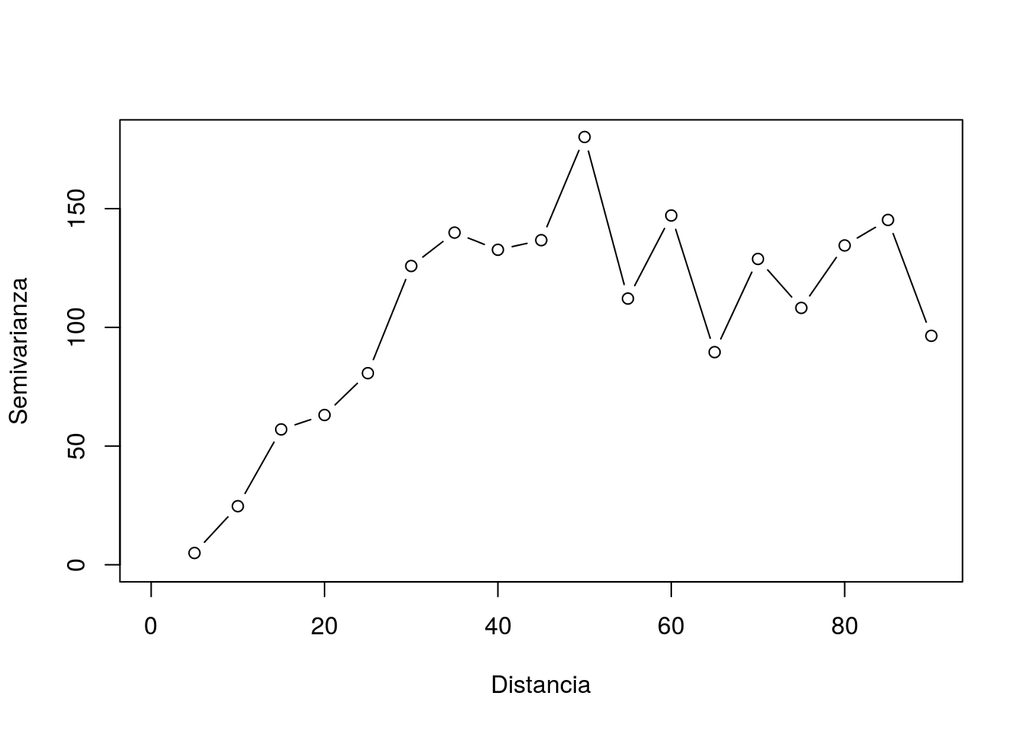

## Semivariograma empírico

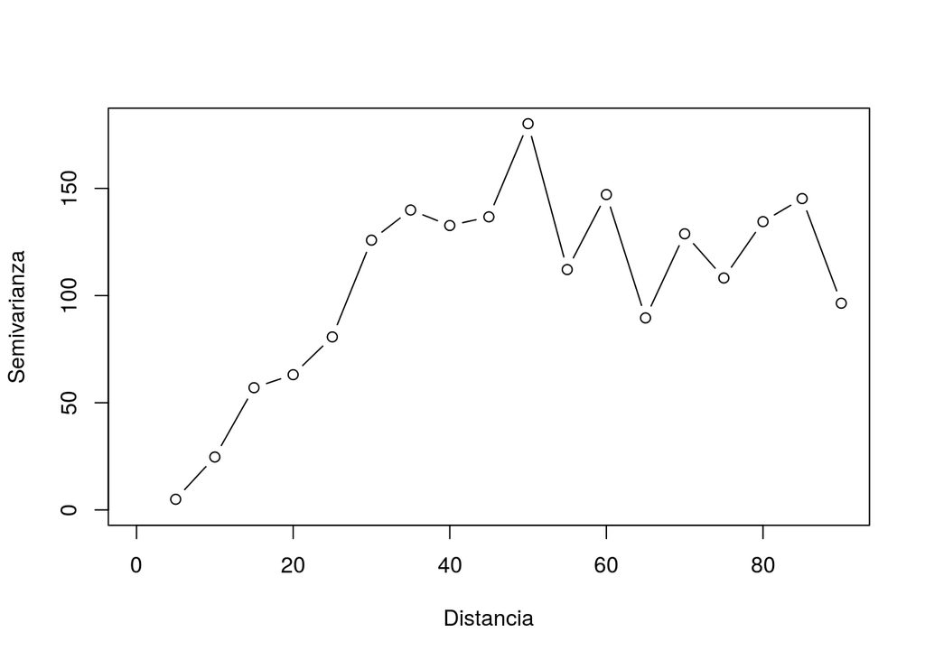

- **Silo**: El valor de γ más pequeño tal que el modelo comienza a aplanarse.
- **Rango**: La distancia en la cual el modelo comienza a aplanarse.
- **Nugget (o pepita)**: El valor en el que el semivariograma (casi) intercepta el eje y.

## Kriging espacio-temporal con **gstat**

- **Gräler, Pebesma, Heuvelink (2016)** implementaron la funcionalidad de kriging espacio temporal en R en el paquete gstat.
- Utiliza el paquete **spacetime** para el manejo de datos espacio temporales.
- Tiene métodos para estimar los semivariogramas y hacer el cómputo numérico para el modelo de kriging.

## **Proximidad**

- Por lo general, suponemos que observaciones espacialmente **cercanas están más asociadas** entre sí que observaciones muy lejanas (**ley de Tobler**).
- Extendemos este supuesto de lo espacial \(S\) a lo espacio-temporal \(S\times T\) al espacio. Por lo tanto, suponemos que la temperatura de hoy está asociada con mayor magnitud con la temperatura de mañana que con las temperaturas de la próxima semana.

## Variograma

En kriging usual la semivarianza se define como

\[ \gamma(h) = \dfrac{1}{2} \mbox{Var}(\eta(s) − \eta(s+h)), \]

y en kriging espacio temporal, como

\[ \gamma(h,u) = \dfrac{1}{2} \mbox{Var}(\eta(s,t) − \eta(s+h, t+u)) \] para cualquier punto \((s,t)\).

## Modelos paramétricos de variograma

- Métrico, las distancias espaciales, temporales y espacio temporales se tratan por igual: \[C_{\rm m}(h,u)=C_{\rm joint}\left(\sqrt{h^2+(\kappa\cdot u)^2}\right)\] Su variograma es: \[ \gamma_{\rm m} (h,u) = \gamma_{\rm joint}\left(\sqrt{h^2+(\kappa\cdot u)^2}\right) \]
- Separable, la función de covarianza se puede representar como el producto de un término espacial y uno temporal: \[C_{\rm sep}(h,u)=C_{\rm s}(h)C_t(u)\] Su variograma está dado por: \[\gamma_{\rm sep}(h,u) = {\rm sill} \cdot \left( \bar{\gamma}_s(h)+\bar{\gamma}_t(u)-\bar{\gamma}_s(h)\bar{\gamma}_t(u) \right)\]

## Modelos paramétricos de variograma

- Suma-producto, supone funciones de covarianza espacial y temporal idénticas, excepto para la anisotropía espacio-temporal: \[C_{\rm m}(h,u)=C_{\rm joint}\left(\sqrt{h^2+(\kappa\cdot u)^2}\right)\] El variograma correspondiente se puede escribir como \[ \gamma_{\rm m} (h,u) = \gamma_{\rm joint}\left(\sqrt{h^2+(\kappa\cdot u)^2}\right) \]
- Métrico-suma, una combinación de modelo espacial, temporal y métrico que incluye un parámetro de anisotropía \(\kappa\) \[C_{\rm sm}(h,u)=C_{\rm s}(h)+C_{\rm t}(u)+C_{\rm joint}\left(\sqrt{h^2+(\kappa\cdot u)^2}\right)\] El variograma está dado por: \[ \gamma_{\rm sm}(h,u)= \gamma_{\rm s}(h) + \gamma_{\rm t}(u) + \gamma_{\rm joint}\left(\sqrt{h^2+(\kappa\cdot u)^2}\right)\]

## Ejemplo: temperatura en México

Leemos los datos:

| estacion | tmedia | fecha_obs | prec | lat | lon | nombre |
| --- | --- | --- | --- | --- | --- | --- |
| CEMPB | 11.5 | 2018-01-04 | 0 | 18.96889 | -97.95833 | Cemex, Pue. |
| PUOPB | 13.5 | 2017-12-29 | 0 | 19.05000 | -98.16667 | Observatorio de Puebla, Pue. |
| VINSI | 22.2 | 2017-12-29 | 0 | 24.74750 | -107.05972 | Vinoramas, Sin. |
| TAPCP | 29.2 | 2018-01-01 | 0 | 14.90000 | -92.18333 | Tapachula, Chis. |
| ACHZC | 14.5 | 2017-12-31 | 0 | 22.32722 | -103.22528 | Achimec, Zac. |
| TMCCH | 10.3 | 2018-01-02 | 0 | 28.95000 | -107.85000 | Temósachic, Chih. |
| HDZSI | 24.0 | 2018-01-02 | 0 | 25.98333 | -109.33333 | Higuera de Zaragoza, Sin. |

## Estaciones climatológicas

```r
mex <- get_map(location = c(-118.41,14.58,-86.72,32.72),
               source = 'google', force = T, crop = T)
edo_shp <- readOGR("datos/estados_ligero", layer = "estados_ligero")
edo_shp@data$id <- rownames(edo_shp@data)
edo_datos <- edo_shp@data
edo_df <- fortify(edo_shp,region="id")
```

[figure not shown]

## Creación de data frame espacio-temporal (STIDF)

```r
wgs_84 <- crs("+proj=longlat +ellps=WGS84 +datum=WGS84 +no_defs")
tempSP <- SpatialPoints(tabla_conagua[,c('lon','lat')], wgs_84)
tempTM <- as.POSIXlt(tabla_conagua$fecha_obs)
panel_temp <- tabla_conagua %>% dplyr::select(tmedia, prec)
tempDF <- STIDF(sp=tempSP, time=tempTM, data=panel_temp)
str(tempDF@data)
```

```
## Classes 'tbl_df', 'tbl' and 'data.frame':    4826 obs. of  2 variables:
##  $ tmedia: num  16 14.4 16.8 16 11.5 ...
##  $ prec  : num  0 0 0 0 0 0 0 0 0 0 ...
```

```r
str(tempDF@time)
```

```
## An 'xts' object on 2017-12-29/2018-01-04 containing:
##   Data: int [1:4826, 1] 2788 2789 2790 2791 2792 2793 2794 2795 2796 2797 ...
##  - attr(*, "dimnames")=List of 2
##   ..$ : NULL
##   ..$ : chr "timeIndex"
##   Indexed by objects of class: [POSIXlt,POSIXt] TZ: UTC
##   xts Attributes:
##  NULL
```

## Creación de data frame espacio-temporal (STIDF)

```r
str(tempDF@sp)
```

```
## Formal class 'SpatialPoints' [package "sp"] with 3 slots
##   ..@ coords     : num [1:4826, 1:2] -102 -102 -103 -102 -102 ...
##   .. ..- attr(*, "dimnames")=List of 2
##   .. .. ..$ : NULL
##   .. .. ..$ : chr [1:2] "lon" "lat"
##   ..@ bbox       : num [1:2, 1:2] -116.9 14.9 -86.8 32.7
##   .. ..- attr(*, "dimnames")=List of 2
##   .. .. ..$ : chr [1:2] "lon" "lat"
##   .. .. ..$ : chr [1:2] "min" "max"
##   ..@ proj4string:Formal class 'CRS' [package "sp"] with 1 slot
##   .. .. ..@ projargs: chr "+proj=longlat +ellps=WGS84 +datum=WGS84 +no_defs +towgs84=0,0,0"
```

## Semivariograma empírico

```r
vv <- variogram(tmedia~1, tempDF, tunit="days", twindow=80, tlags=0:2)
```

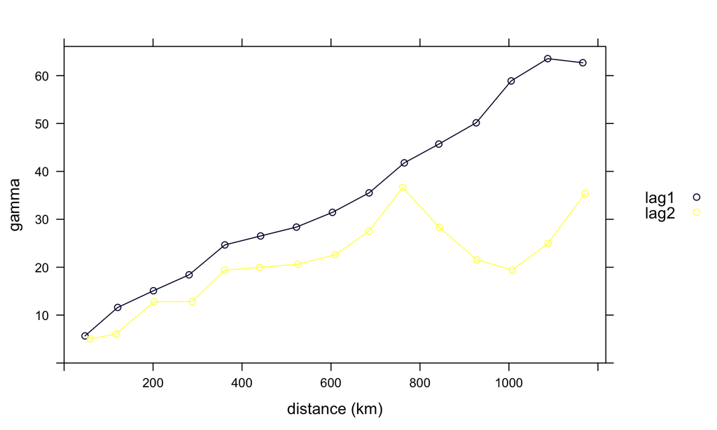

```r
plot(vv, map=FALSE)
```

## Semivariograma empírico

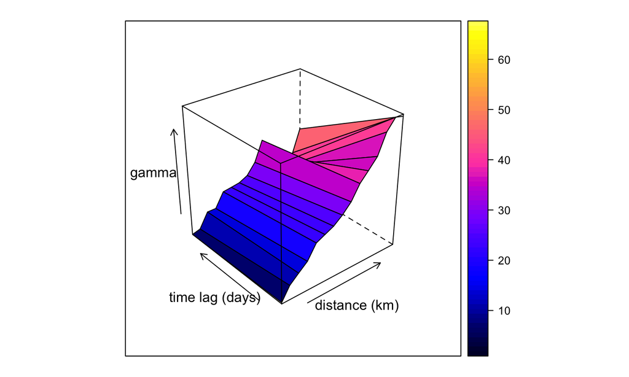

```r
plot(vv,wireframe=T)
```

## Semivariograma empírico

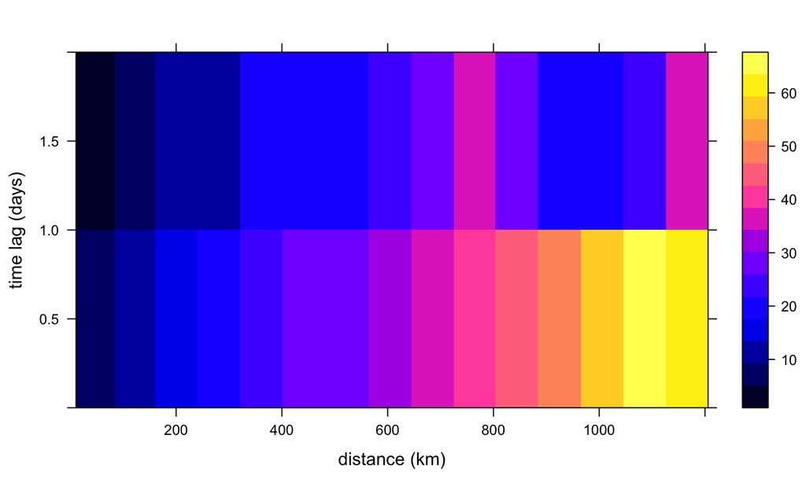

```r
plot(vv)
```

## Ajuste del semivariograma

```r
SimplesumMetric <- vgmST("simpleSumMetric",
                         space = vgm(50,"Sph", 200, 0),
                         time = vgm(200,"Sph", 200, 0),
                         joint = vgm(1,"Sph", 200, 0),
                         nugget=0.1,
                         stAni=200)

pars.l <- c(sill.s = 50, range.s = 800, nugget.s = 0,
            sill.t = 0, range.t = 1, nugget.t = 0,
            sill.st = 0, range.st = 10, nugget.st = 0,
            anis = 0)

vgm <- fit.StVariogram(vv, SimplesumMetric, method = "L-BFGS-B",lower=pars.l)
```

## Ajuste del semivariograma

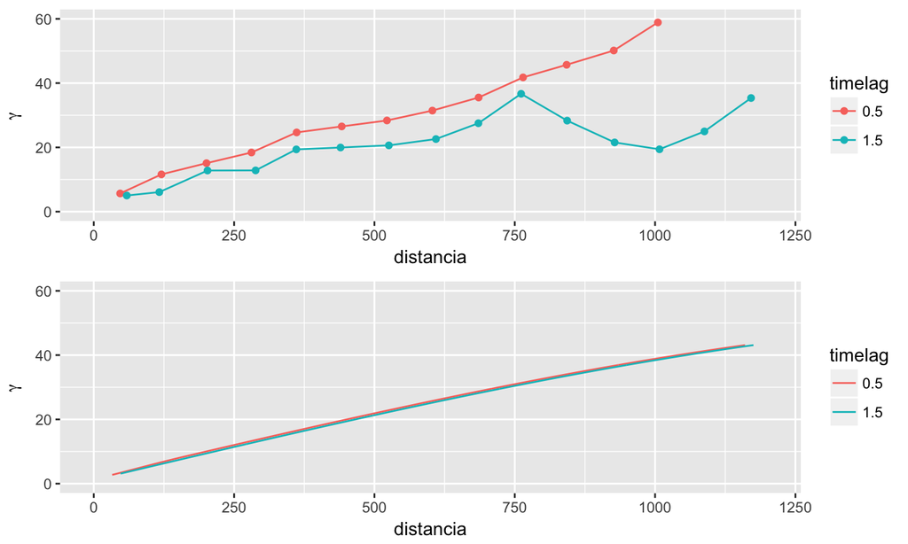

## Ajuste del modelo y predicción

```r
grid_sp <- spsample(edo_shp, n = 800, type = "regular")
```

```r
grid_tm <- seq(ymd('2017-12-29'),ymd('2018-1-4'), by = '2 days')
grid_tm <- as.POSIXlt(grid_tm)
```

```r
grid_ST <- STF(grid_sp, grid_tm)
```

## Ajuste del modelo y predicción

```r
pred <- krigeST(tmedia~1, data=tempDF, modelList=vgm, newdata=grid_ST)
```

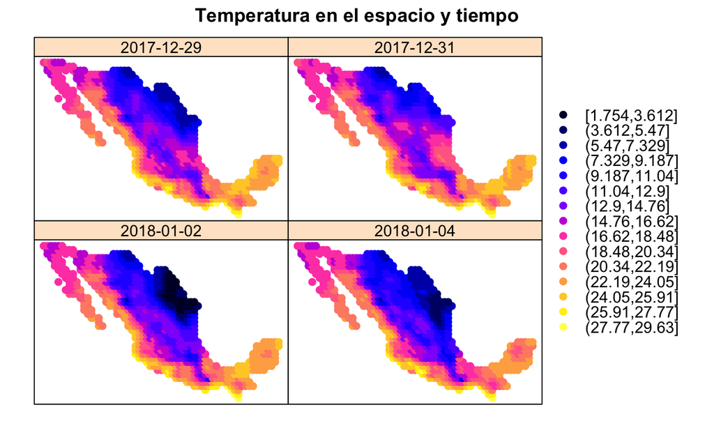

```r
stplot(pred, main = "Temperatura en el espacio y tiempo")
```

**Código, presentación y notas en:**

github.com/andreuboada/st-kriging.

[figure not shown]